# Linear model in R

Michael Blum

15/11/2018

We will show how to work with linear models in R.

# Linear regression with *lm*

Here, we will consider the result of the 2nd round of the French presidential 2017 election. The variables include socio-economic variables and the score of the 2nd round of the French presidential election. If you want to read more about the dataset, you can have a look to [my paper](https://towardsdatascience.com/machine-learning-approaches-detect-outlier-values-that-do-not-follow-a-common-trend-detecting-cc0252f637bd) in Medium.

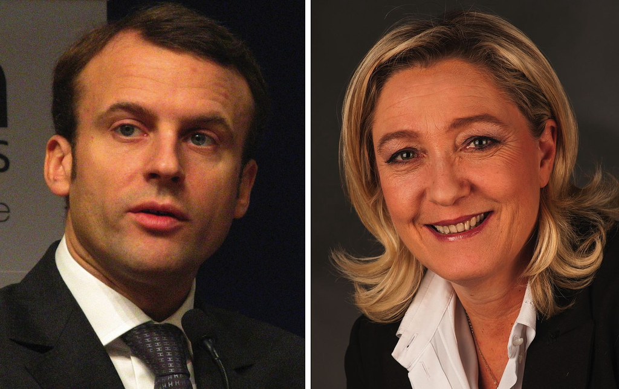

## Find the most correlated variables

```r
  data <- read.csv(file="data/presidential2017_dept.csv")[,-1]
  thecor <- cor((data[,]))
  sort(thecor[1,]^2,decreasing=T)[1:10]
```

```
##                             Score_LePen
##                               1.0000000
##               Prop.Sante.action.sociale
##                               0.2902821
##    Prop.Occupants.R..sidence.Principale
##                               0.2783635
##                         Score.Urbanit..
##                               0.2484593
##                          PIB.R..gionnal
##                               0.2308855
##                               Score.PIB
##                               0.2308855
## Prop.Services.personnels.et.domestiques
##                               0.2288104
##  Prop.Education..sant....action.sociale
##                               0.2280362
##              Valeur.ajout..e.r..gionale
##                               0.2180179
##                        Score.VA.R..gion
##                               0.2180179
```

Would you think, we will obtain the same most correlated variables if regressing the score of Emmanuel Macron instead of Marine Le Pen?

Vote online!

https://fr.surveymonkey.com/r/RBNVHWT

## Relationship between vote for Marine Le Pen and proportion of health/social workers

Let us plot the relationship between the 2 variables.

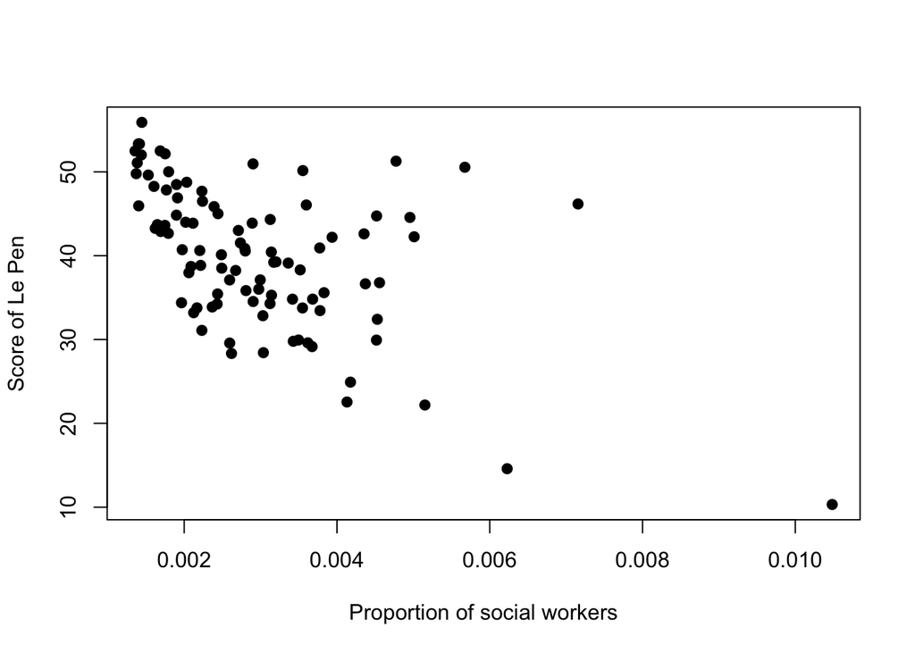

```r
plot(data$Prop.Sant,data[,"Score_LePen"],pch=19,xlab="Proportion of social workers",ylab="Score of Le Pen")
```

## Simple linear regression

```r
myfit<-lm(Score_LePen ~ Prop.Sante.action.sociale, data=data)
summary(myfit)
```

```
##
## Call:
## lm(formula = Score_LePen ~ Prop.Sante.action.sociale, data = data)
##
## Residuals:
##      Min       1Q   Median       3Q      Max
## -14.6430  -4.7119  -0.0121   4.8937  19.9905
##
## Coefficients:
##                           Estimate Std. Error t value Pr(>|t|)
## (Intercept)                  49.72       1.74  28.585  < 2e-16 ***
## Prop.Sante.action.sociale -3290.11     530.62  -6.201 1.49e-08 ***
## ---
## Signif. codes:  0 '***' 0.001 '**' 0.01 '*' 0.05 '.' 0.1 ' ' 1
##
## Residual standard error: 7.223 on 94 degrees of freedom
## Multiple R-squared:  0.2903, Adjusted R-squared:  0.2827
## F-statistic: 38.45 on 1 and 94 DF,  p-value: 1.491e-08
```

The third column is the **t value** that is the ratio between the first column (regression coefficient) and the second one (standard deviation of the regression coefficient). The last column is the P value, which is the probability, under the null hypothesis, to have a t value larger in absolute value than the observed one.

What do you expect for P-values under the null?

Vote online!

https://fr.surveymonkey.com/r/R69FS3T

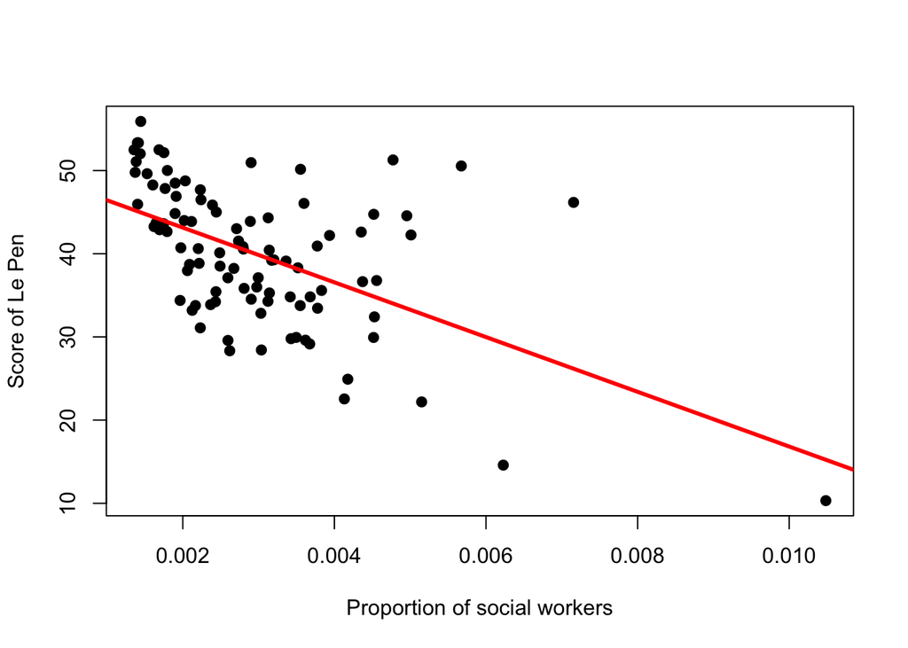

```r
plot(data[,"Prop.Sante.action.sociale"],data[,"Score_LePen"],pch=19,xlab="Proportion of social workers",ylab="Score of Le Pen")
abline(myfit,lwd=3,col=2)
```

## Adding a categorical variable in a linear model

```r
#Department
dept <- (read.csv(file="data/presidential2017_dept.csv")[,1])

#Make a new relevant categorical variablde
categ <- as.factor(as.numeric(dept)%%3)

myfit<-lm(Score_LePen ~ Prop.Sante.action.sociale  + categ, data=data)
summary(myfit)
```

```
##
## Call:
## lm(formula = Score_LePen ~ Prop.Sante.action.sociale + categ,
##     data = data)
##
## Residuals:
##      Min       1Q   Median       3Q      Max
## -14.1748  -4.4339  -0.3806   4.8130  20.2882
##
## Coefficients:
##                             Estimate Std. Error t value Pr(>|t|)
## (Intercept)                  49.1144     2.0570  23.877  < 2e-16 ***
## Prop.Sante.action.sociale -3322.5493   543.6639  -6.111 2.35e-08 ***
## categ1                        1.3343     1.8288   0.730    0.467
## categ2                        0.7813     1.8262   0.428    0.670
## ---
## Signif. codes:  0 '***' 0.001 '**' 0.01 '*' 0.05 '.' 0.1 ' ' 1
##
## Residual standard error: 7.279 on 92 degrees of freedom
## Multiple R-squared:  0.2944, Adjusted R-squared:  0.2714
## F-statistic:  12.8 on 3 and 92 DF,  p-value: 4.632e-07
```

The p-values related to the categorical variable are difficult to interpret. We should use anlaysis of variance instead

```r
anova(myfit)
```

```
## Analysis of Variance Table
##
## Response: Score_LePen
##                           Df Sum Sq Mean Sq F value    Pr(>F)
## Prop.Sante.action.sociale  1 2005.6 2005.58 37.8495 1.959e-08 ***
## categ                      2   28.6   14.28  0.2696    0.7643
## Residuals                 92 4874.9   52.99
## ---
## Signif. codes:  0 '***' 0.001 '**' 0.01 '*' 0.05 '.' 0.1 ' ' 1
```

## Choosing the most important variables using AIC

```r
fitall<-lm(Score_LePen ~ .,data=data)
summary(fitall)

reduced<-stepAIC(fitall)
```

```r
summary(reduced)$call
```

```
## lm(formula = Score_LePen ~ Prop.Pharmacies.et.parfumerie + Dynamique.Entrepreneuriale.Service.et.Commerce +
##     Indice.Fiscal.Partiel + Indice.Evasion.Client + Prop.Omnipraticiens.BV +
##     Prop.Infirmiers.Lib..raux.BV + Prop.dentistes.Lib..raux.BV +
##     Densit...M..dicale.BV + Score...quipement.de.sant...BV +
##     Indice.D..mographique + Evolution.Population + Evolution.Pop.. +
##     Prop.M..nages + Prop.R..sidences.Principales + Prop.propri..taire +
##     Prop.Logement + Prop.R..sidences.Secondaires + Prop.Femme +
##     Prop.Etudiants + Prop.Entreprises.Secteur.Commerce + Prop.Entreprises.Secteur.Construction +
##     Prop.Entreprises.Secteur.Industrie + Prop.Cr..ation.Enteprises +
##     Prop.Cr..ation.Industrielles + Prop.Cr..ation.Construction +
##     Prop.Cr..ation.Commerces + Moyenne.Revenus.Fiscaux.D..partementaux +
##     Dep.Moyenne.Salaires.Horaires + Dep.Moyenne.Salaires.Employ...Horaires +
##     Dep.Moyenne.Salaires.Ouvri...Horaires + Reg.Moyenne.Salaires.Horaires +
##     Reg.Moyenne.Salaires.Cadre.Horaires + Prop.Atifs + Prop.Logement.Secondaire.et.Occasionnel +
##     Prop.Hotel + Capacit...Hotel + Prop.Camping + Capacit...Camping +
##     Taux...tudiants + Taux.Propri..t.. + Dynamique.D..mographique.INSEE +
##     Capacit...Fisc + Prop.Education..sant....action.sociale +
##     Prop.Services.personnels.et.domestiques + Prop.Sante.action.sociale +
##     Prop.Industries.des.biens.interm..diaires + Prop.de.Commerce +
##     Prop.de.Services.aux.particuliers + Prop.institution.de.Education..sant....action.sociale..administration +
##     PIB.R..gionnal + Score.Croissance.Entrepreneuriale, data = data)
```

The result is a bit disappointing because the preferred model is a model with many variables.

## Choosing the most important variables using lasso (*glmnet*)

```r
x<-as.matrix(data[,-1])
y<-data[,1]
myfit<-glmnet::glmnet(x=x,y=y)
cvfit = glmnet::cv.glmnet(x, y)
coef(cvfit, s = "lambda.min")
```

```
## 85 x 1 sparse Matrix of class "dgCMatrix"
##                                                                                1
## (Intercept)                                                            -34.61242
## Prop.Pharmacies.et.parfumerie                                            .
## Dynamique.Entrepreneuriale                                               .
## Dynamique.Entrepreneuriale.Service.et.Commerce                           .
## Synergie.M..dicale.COMMUNE                                               .
## Indice.Fiscal.Partiel                                                    .
## Score.Fiscal                                                             .
## Indice.Evasion.Client                                                    .
## Score.Evasion.Client                                                     .
## Indice.Synergie.M..dicale                                                .
## Score.Synergie.M..dicale                                                 .
## Prop.Omnipraticiens.BV                                                   .
## Prop.Infirmiers.Lib..raux.BV                                             .
## Prop.dentistes.Lib..raux.BV                                              .
## Prop.pharmaciens.Lib..raux.BV                                            .
## Densit...M..dicale.BV                                                    .
## Score...quipement.de.sant...BV                                           .
## Indice.D..mographique                                                    .
## Score.D..mographique                                                     .
## Indice.M..nages                                                          .
## Score.M..nages                                                           .
## Population                                                               .
## Evolution.Population                                                     .
## Evolution.Pop..                                                          .
## Prop.M..nages                                                            .
## Prop.R..sidences.Principales                                             .
## Prop.propri..taire                                                       .
## Prop.Logement                                                            .
## Prop.R..sidences.Secondaires                                             .
## Prop.Log.Vacants                                                         .
## Prop.Occupants.R..sidence.Principale                                    76.76565
## Prop.Femme                                                               .
## Prop.Homme                                                               .
## Prop.Mineurs                                                             .
## Prop.Majeurs                                                             .
## Prop.Etudiants                                                           .
## Prop.Entreprises.Secteur.Services                                        .
## Prop.Entreprises.Secteur.Commerce                                        .
```

[output cut: 32 more lines]

```
## Capacit...Fisc                                                           .
## Moyenne.Revnus.fiscaux                                                   .
## Taux.Evasion.Client                                                      .
## Prop.Education..sant....action.sociale                                   .
## Prop.Services.personnels.et.domestiques                                  .
## Prop.Sante.action.sociale                                             -414.86613
## Prop.Industries.des.biens.interm..diaires                                .
## Prop.de.Commerce                                                         .
## Prop.de.Services.aux.particuliers                                        .
## Prop.institution.de.Education..sant....action.sociale..administration    .
## PIB.R..gionnal                                                           .
## Score.Croissance.Population                                              .
## Score.Croissance.Entrepreneuriale                                        .
## Score.VA.R..gion                                                         .
## Score.PIB                                                                .
```

## Cross validation to evaluate model predictive accuracy using *caret*

```r
# load the library
# define training control
train_control <- caret::trainControl(method="LOOCV")
# train the model
model <- caret::train(Score_LePen~., data=data, trControl=train_control, method="lm")
```

```r
# summarize results
print(model)
```

```
## Linear Regression
##
## 96 samples
## 84 predictors
##
## No pre-processing
## Resampling: Leave-One-Out Cross-Validation
## Summary of sample sizes: 95, 95, 95, 95, 95, 95, ...
## Resampling results:
##
##   RMSE      Rsquared   MAE
##   2780.555  0.1283309  291.0158
##
## Tuning parameter 'intercept' was held constant at a value of TRUE
```

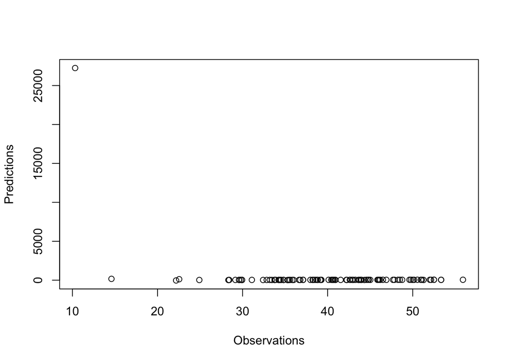

```r
#Plot predictions as a function of observations
plot(model$pred$obs,model$pred$pred,xlab="Observations",ylab="Predictions")
```

Some data are poorly predicted and it includes department in Paris and around. We remove them and evaluate predictive accuracy again.

```r
# suppress some depts
datanew<-data[!dept%in%c("75","91","92","93","94","95"),]
deptnew<-dept[!dept%in%c("75","91","92","93","94","95")]
train_control <- caret::trainControl(method="LOOCV")
# train the model
model <- caret::train(Score_LePen~., data=datanew, trControl=train_control, method="lm")
# summarize results
```

```r
# summarize results
print(model)
```

```
## Linear Regression
##
## 90 samples
## 84 predictors
##
## No pre-processing
## Resampling: Leave-One-Out Cross-Validation
## Summary of sample sizes: 89, 89, 89, 89, 89, 89, ...
## Resampling results:
##
##   RMSE      Rsquared   MAE
##   7.195789  0.4273819  5.694694
##
## Tuning parameter 'intercept' was held constant at a value of TRUE
```

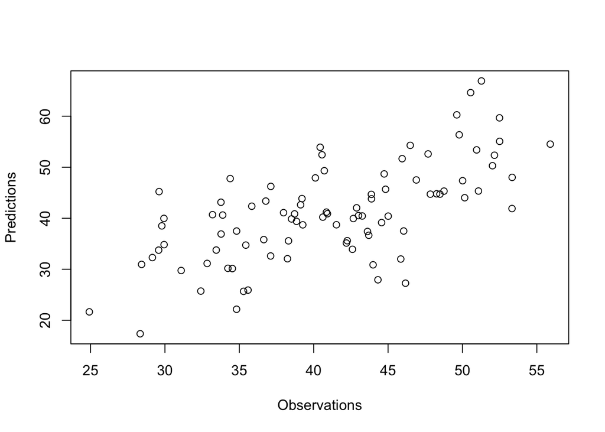

```r
#Plot predictions as a function of observations
plot(model$pred$obs,model$pred$pred,xlab="Observations",ylab="Predictions")
```

Now predictions with socio economic variables works better with a R^2 of 0.42.

# Logistic regression with *glm*

Assume we know only if the score is larger than $40\%$or not. Based on this binary data, find the most related variables, propose a reduced model, and evaluate classification accuracy.

```r
data[,1] <- as.factor(data[,1]>=40)
```